# Risk Factor Analysis

## Outcome Variable

**Outcome Variable:** ever_sstunted

## Predictor Variables

**Intervention Variable:** nhh

**Adjustment Set:**

- arm
- W_mage
- meducyrs
- feducyrs
- W_mhtcm
- W_mwtkg
- W_mbmi
- W_nrooms
- impfloor
- impsan
- safeh20
- delta_W_mage
- delta_meducyrs
- delta_feducyrs
- delta_W_mhtcm
- delta_W_mwtkg
- delta_W_mbmi
- delta_W_nrooms
- delta_impfloor
- delta_impsan
- delta_safeh20

## Stratifying Variables

The analysis was stratified on these variable(s):

- agecat
- studyid
- country

## Data Summary

| agecat | studyid | country | nhh | ever_sstunted | n_cell | n |
| --- | --- | --- | --- | --- | --- | --- |
| 0-24 months | IRC | INDIA | 3 or less | 0 | 47 | 410 |
| 0-24 months | IRC | INDIA | 3 or less | 1 | 11 | 410 |
| 0-24 months | IRC | INDIA | 4-5 | 0 | 114 | 410 |
| 0-24 months | IRC | INDIA | 4-5 | 1 | 44 | 410 |
| 0-24 months | IRC | INDIA | 6-7 | 0 | 80 | 410 |
| 0-24 months | IRC | INDIA | 6-7 | 1 | 27 | 410 |
| 0-24 months | IRC | INDIA | 8+ | 0 | 67 | 410 |
| 0-24 months | IRC | INDIA | 8+ | 1 | 20 | 410 |
| 0-24 months | LCNI-5 | MALAWI | 3 or less | 0 | 183 | 817 |
| 0-24 months | LCNI-5 | MALAWI | 3 or less | 1 | 42 | 817 |
| 0-24 months | LCNI-5 | MALAWI | 4-5 | 0 | 263 | 817 |
| 0-24 months | LCNI-5 | MALAWI | 4-5 | 1 | 77 | 817 |
| 0-24 months | LCNI-5 | MALAWI | 6-7 | 0 | 146 | 817 |
| 0-24 months | LCNI-5 | MALAWI | 6-7 | 1 | 36 | 817 |
| 0-24 months | LCNI-5 | MALAWI | 8+ | 0 | 55 | 817 |
| 0-24 months | LCNI-5 | MALAWI | 8+ | 1 | 15 | 817 |
| 0-24 months | NIH-Birth | BANGLADESH | 3 or less | 0 | 87 | 629 |
| 0-24 months | NIH-Birth | BANGLADESH | 3 or less | 1 | 30 | 629 |
| 0-24 months | NIH-Birth | BANGLADESH | 4-5 | 0 | 172 | 629 |
| 0-24 months | NIH-Birth | BANGLADESH | 4-5 | 1 | 92 | 629 |
| 0-24 months | NIH-Birth | BANGLADESH | 6-7 | 0 | 98 | 629 |
| 0-24 months | NIH-Birth | BANGLADESH | 6-7 | 1 | 44 | 629 |
| 0-24 months | NIH-Birth | BANGLADESH | 8+ | 0 | 76 | 629 |
| 0-24 months | NIH-Birth | BANGLADESH | 8+ | 1 | 30 | 629 |
| 0-24 months | NIH-Crypto | BANGLADESH | 3 or less | 0 | 102 | 758 |
| 0-24 months | NIH-Crypto | BANGLADESH | 3 or less | 1 | 12 | 758 |
| 0-24 months | NIH-Crypto | BANGLADESH | 4-5 | 0 | 295 | 758 |
| 0-24 months | NIH-Crypto | BANGLADESH | 4-5 | 1 | 47 | 758 |
| 0-24 months | NIH-Crypto | BANGLADESH | 6-7 | 0 | 153 | 758 |
| 0-24 months | NIH-Crypto | BANGLADESH | 6-7 | 1 | 25 | 758 |

[output cut: 66 more lines]

The following strata were considered:

- agecat: 0-24 months, studyid: IRC, country: INDIA
- agecat: 0-24 months, studyid: LCNI-5, country: MALAWI
- agecat: 0-24 months, studyid: NIH-Birth, country: BANGLADESH
- agecat: 0-24 months, studyid: NIH-Crypto, country: BANGLADESH
- agecat: 0-24 months, studyid: PROVIDE, country: BANGLADESH
- agecat: 0-24 months, studyid: SAS-FoodSuppl, country: INDIA
- agecat: 0-6 months, studyid: IRC, country: INDIA
- agecat: 0-6 months, studyid: LCNI-5, country: MALAWI
- agecat: 0-6 months, studyid: NIH-Birth, country: BANGLADESH
- agecat: 0-6 months, studyid: NIH-Crypto, country: BANGLADESH
- agecat: 0-6 months, studyid: PROVIDE, country: BANGLADESH
- agecat: 0-6 months, studyid: SAS-FoodSuppl, country: INDIA

### Dropped Strata

Some strata were dropped due to rare outcomes:

- agecat: 0-6 months, studyid: LCNI-5, country: MALAWI
- agecat: 0-6 months, studyid: PROVIDE, country: BANGLADESH
- agecat: 0-6 months, studyid: SAS-FoodSuppl, country: INDIA

## Methods Detail

We’re interested in the causal parameters $E[Y_a]$ for all values of $a \in \mathcal{A}$. These parameters represent the mean outcome if, possibly contrary to fact, we intervened to set all units to have $A=a$. Under the randomization and positivity assumptions, these are identified by the statistical parameters $\psi_a=E_W[E_{Y|A,W}(Y|A=a,W)]$. In addition, we’re interested in the mean of $Y$, $E[Y]$ under no intervention (the observed mean). We will estimate these parameters by using SuperLearner to fit the relevant likelihood factors – $E_{Y|A,W}(Y|A=a,W)$ and $p(A=a|W)$, and then updating our likelihood fit using a joint TMLE.

For unadjusted analyses ($W=\{\}$), initial likelihoods were estimated using Lrnr_glm to estimate the simple $E(Y|A)$ and Lrnr_mean to estimate $p(A)$. For adjusted analyses, a small library containing Lrnr_glmnet, Lrnr_xgboost, and Lrnr_mean was used.

Having estimated these parameters, we will then use the delta method to estimate relative risks and attributable risks relative to a prespecified baseline level of $A$.

# Results Detail

## Results Plots

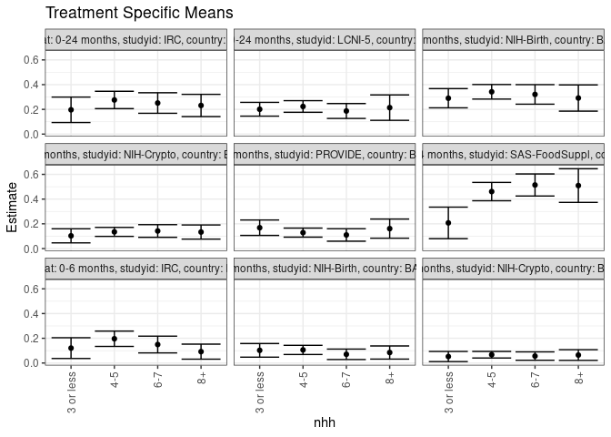

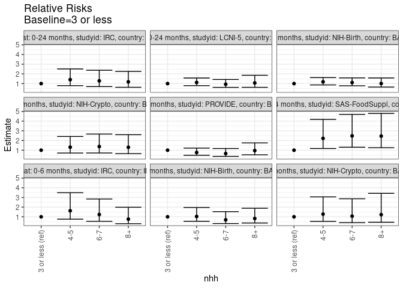

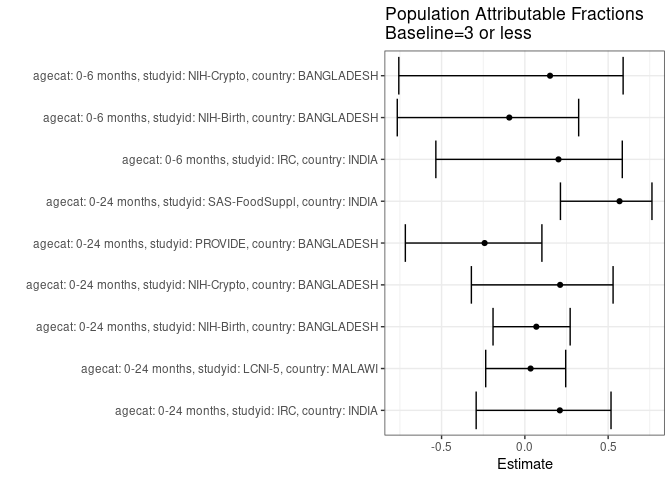

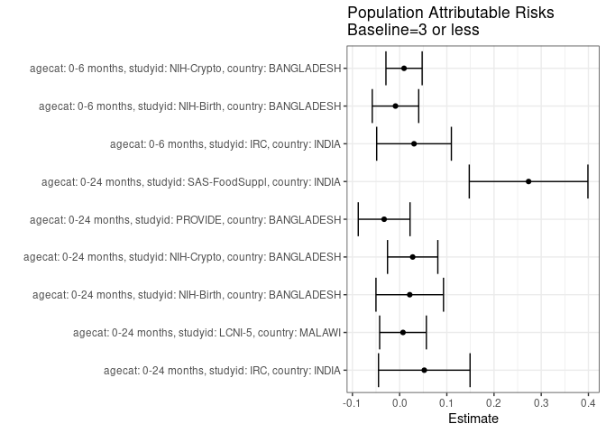

## Results Table

### Parameter: TSM

| agecat | studyid | country | intervention_level | baseline_level | estimate | ci_lower | ci_upper |
| --- | --- | --- | --- | --- | --- | --- | --- |
| 0-24 months | IRC | INDIA | 3 or less | NA | 0.1965086 | 0.0937062 | 0.2993110 |
| 0-24 months | IRC | INDIA | 4-5 | NA | 0.2760657 | 0.2059227 | 0.3462086 |
| 0-24 months | IRC | INDIA | 6-7 | NA | 0.2514798 | 0.1684901 | 0.3344695 |
| 0-24 months | IRC | INDIA | 8+ | NA | 0.2315121 | 0.1415651 | 0.3214592 |
| 0-24 months | LCNI-5 | MALAWI | 3 or less | NA | 0.2009122 | 0.1451496 | 0.2566749 |
| 0-24 months | LCNI-5 | MALAWI | 4-5 | NA | 0.2234544 | 0.1764771 | 0.2704317 |
| 0-24 months | LCNI-5 | MALAWI | 6-7 | NA | 0.1868550 | 0.1266013 | 0.2471088 |
| 0-24 months | LCNI-5 | MALAWI | 8+ | NA | 0.2140832 | 0.1113393 | 0.3168271 |
| 0-24 months | NIH-Birth | BANGLADESH | 3 or less | NA | 0.2901794 | 0.2125501 | 0.3678087 |
| 0-24 months | NIH-Birth | BANGLADESH | 4-5 | NA | 0.3421603 | 0.2833505 | 0.4009702 |
| 0-24 months | NIH-Birth | BANGLADESH | 6-7 | NA | 0.3209745 | 0.2419322 | 0.4000169 |
| 0-24 months | NIH-Birth | BANGLADESH | 8+ | NA | 0.2917922 | 0.1858380 | 0.3977465 |
| 0-24 months | NIH-Crypto | BANGLADESH | 3 or less | NA | 0.1029617 | 0.0460810 | 0.1598424 |
| 0-24 months | NIH-Crypto | BANGLADESH | 4-5 | NA | 0.1348777 | 0.0985695 | 0.1711858 |
| 0-24 months | NIH-Crypto | BANGLADESH | 6-7 | NA | 0.1421600 | 0.0909459 | 0.1933742 |
| 0-24 months | NIH-Crypto | BANGLADESH | 8+ | NA | 0.1335791 | 0.0763768 | 0.1907814 |
| 0-24 months | PROVIDE | BANGLADESH | 3 or less | NA | 0.1685151 | 0.1060873 | 0.2309428 |
| 0-24 months | PROVIDE | BANGLADESH | 4-5 | NA | 0.1288977 | 0.0923300 | 0.1654655 |
| 0-24 months | PROVIDE | BANGLADESH | 6-7 | NA | 0.1099745 | 0.0595231 | 0.1604260 |
| 0-24 months | PROVIDE | BANGLADESH | 8+ | NA | 0.1613487 | 0.0839810 | 0.2387164 |
| 0-24 months | SAS-FoodSuppl | INDIA | 3 or less | NA | 0.2076089 | 0.0801050 | 0.3351128 |
| 0-24 months | SAS-FoodSuppl | INDIA | 4-5 | NA | 0.4608645 | 0.3867085 | 0.5350206 |
| 0-24 months | SAS-FoodSuppl | INDIA | 6-7 | NA | 0.5141314 | 0.4248203 | 0.6034424 |
| 0-24 months | SAS-FoodSuppl | INDIA | 8+ | NA | 0.5094730 | 0.3732863 | 0.6456597 |
| 0-6 months | IRC | INDIA | 3 or less | NA | 0.1206897 | 0.0367494 | 0.2046299 |
| 0-6 months | IRC | INDIA | 4-5 | NA | 0.1962025 | 0.1342049 | 0.2582002 |
| 0-6 months | IRC | INDIA | 6-7 | NA | 0.1495327 | 0.0818803 | 0.2171851 |
| 0-6 months | IRC | INDIA | 8+ | NA | 0.0919540 | 0.0311604 | 0.1527476 |
| 0-6 months | NIH-Birth | BANGLADESH | 3 or less | NA | 0.1025641 | 0.0475467 | 0.1575815 |
| 0-6 months | NIH-Birth | BANGLADESH | 4-5 | NA | 0.1060606 | 0.0688880 | 0.1432332 |
| 0-6 months | NIH-Birth | BANGLADESH | 6-7 | NA | 0.0704225 | 0.0283064 | 0.1125386 |
| 0-6 months | NIH-Birth | BANGLADESH | 8+ | NA | 0.0849057 | 0.0317999 | 0.1380115 |
| 0-6 months | NIH-Crypto | BANGLADESH | 3 or less | NA | 0.0526316 | 0.0116145 | 0.0936487 |
| 0-6 months | NIH-Crypto | BANGLADESH | 4-5 | NA | 0.0672515 | 0.0406898 | 0.0938131 |
| 0-6 months | NIH-Crypto | BANGLADESH | 6-7 | NA | 0.0561798 | 0.0223297 | 0.0900298 |
| 0-6 months | NIH-Crypto | BANGLADESH | 8+ | NA | 0.0645161 | 0.0212472 | 0.1077851 |

### Parameter: E(Y)

| agecat | studyid | country | intervention_level | baseline_level | estimate | ci_lower | ci_upper |
| --- | --- | --- | --- | --- | --- | --- | --- |
| 0-24 months | IRC | INDIA | NA | NA | 0.2487805 | 0.2068840 | 0.2906770 |
| 0-24 months | LCNI-5 | MALAWI | NA | NA | 0.2080783 | 0.1802263 | 0.2359304 |
| 0-24 months | NIH-Birth | BANGLADESH | NA | NA | 0.3116057 | 0.2753823 | 0.3478292 |
| 0-24 months | NIH-Crypto | BANGLADESH | NA | NA | 0.1306069 | 0.1066024 | 0.1546113 |
| 0-24 months | PROVIDE | BANGLADESH | NA | NA | 0.1357143 | 0.1103250 | 0.1611036 |
| 0-24 months | SAS-FoodSuppl | INDIA | NA | NA | 0.4808612 | 0.4329065 | 0.5288160 |
| 0-6 months | IRC | INDIA | NA | NA | 0.1512195 | 0.1164988 | 0.1859402 |
| 0-6 months | NIH-Birth | BANGLADESH | NA | NA | 0.0937997 | 0.0709973 | 0.1166021 |
| 0-6 months | NIH-Crypto | BANGLADESH | NA | NA | 0.0620053 | 0.0448256 | 0.0791849 |

### Parameter: RR

| agecat | studyid | country | intervention_level | baseline_level | estimate | ci_lower | ci_upper |
| --- | --- | --- | --- | --- | --- | --- | --- |
| 0-24 months | IRC | INDIA | 3 or less | 3 or less | 1.0000000 | 1.0000000 | 1.000000 |
| 0-24 months | IRC | INDIA | 4-5 | 3 or less | 1.4048525 | 0.7854295 | 2.512779 |
| 0-24 months | IRC | INDIA | 6-7 | 3 or less | 1.2797390 | 0.6894476 | 2.375426 |
| 0-24 months | IRC | INDIA | 8+ | 3 or less | 1.1781270 | 0.6141170 | 2.260128 |
| 0-24 months | LCNI-5 | MALAWI | 3 or less | 3 or less | 1.0000000 | 1.0000000 | 1.000000 |
| 0-24 months | LCNI-5 | MALAWI | 4-5 | 3 or less | 1.1121992 | 0.7851050 | 1.575569 |
| 0-24 months | LCNI-5 | MALAWI | 6-7 | 3 or less | 0.9300332 | 0.6077047 | 1.423326 |
| 0-24 months | LCNI-5 | MALAWI | 8+ | 3 or less | 1.0655558 | 0.6120647 | 1.855048 |
| 0-24 months | NIH-Birth | BANGLADESH | 3 or less | 3 or less | 1.0000000 | 1.0000000 | 1.000000 |
| 0-24 months | NIH-Birth | BANGLADESH | 4-5 | 3 or less | 1.1791338 | 0.8590914 | 1.618403 |
| 0-24 months | NIH-Birth | BANGLADESH | 6-7 | 3 or less | 1.1061243 | 0.7718978 | 1.585069 |
| 0-24 months | NIH-Birth | BANGLADESH | 8+ | 3 or less | 1.0055580 | 0.6404175 | 1.578887 |
| 0-24 months | NIH-Crypto | BANGLADESH | 3 or less | 3 or less | 1.0000000 | 1.0000000 | 1.000000 |
| 0-24 months | NIH-Crypto | BANGLADESH | 4-5 | 3 or less | 1.3099791 | 0.7094821 | 2.418729 |
| 0-24 months | NIH-Crypto | BANGLADESH | 6-7 | 3 or less | 1.3807079 | 0.7144427 | 2.668309 |
| 0-24 months | NIH-Crypto | BANGLADESH | 8+ | 3 or less | 1.2973668 | 0.6461827 | 2.604775 |
| 0-24 months | PROVIDE | BANGLADESH | 3 or less | 3 or less | 1.0000000 | 1.0000000 | 1.000000 |
| 0-24 months | PROVIDE | BANGLADESH | 4-5 | 3 or less | 0.7649031 | 0.4798316 | 1.219338 |
| 0-24 months | PROVIDE | BANGLADESH | 6-7 | 3 or less | 0.6526094 | 0.3620424 | 1.176379 |
| 0-24 months | PROVIDE | BANGLADESH | 8+ | 3 or less | 0.9574731 | 0.5225972 | 1.754228 |
| 0-24 months | SAS-FoodSuppl | INDIA | 3 or less | 3 or less | 1.0000000 | 1.0000000 | 1.000000 |
| 0-24 months | SAS-FoodSuppl | INDIA | 4-5 | 3 or less | 2.2198691 | 1.1779570 | 4.183361 |
| 0-24 months | SAS-FoodSuppl | INDIA | 6-7 | 3 or less | 2.4764420 | 1.3059865 | 4.695887 |
| 0-24 months | SAS-FoodSuppl | INDIA | 8+ | 3 or less | 2.4540037 | 1.2550738 | 4.798231 |
| 0-6 months | IRC | INDIA | 3 or less | 3 or less | 1.0000000 | 1.0000000 | 1.000000 |
| 0-6 months | IRC | INDIA | 4-5 | 3 or less | 1.6256781 | 0.7572995 | 3.489807 |
| 0-6 months | IRC | INDIA | 6-7 | 3 or less | 1.2389853 | 0.5404161 | 2.840561 |
| 0-6 months | IRC | INDIA | 8+ | 3 or less | 0.7619048 | 0.2918463 | 1.989057 |
| 0-6 months | NIH-Birth | BANGLADESH | 3 or less | 3 or less | 1.0000000 | 1.0000000 | 1.000000 |
| 0-6 months | NIH-Birth | BANGLADESH | 4-5 | 3 or less | 1.0340909 | 0.5448490 | 1.962643 |
| 0-6 months | NIH-Birth | BANGLADESH | 6-7 | 3 or less | 0.6866197 | 0.3074793 | 1.533263 |
| 0-6 months | NIH-Birth | BANGLADESH | 8+ | 3 or less | 0.8278302 | 0.3631514 | 1.887099 |
| 0-6 months | NIH-Crypto | BANGLADESH | 3 or less | 3 or less | 1.0000000 | 1.0000000 | 1.000000 |
| 0-6 months | NIH-Crypto | BANGLADESH | 4-5 | 3 or less | 1.2777778 | 0.5333533 | 3.061228 |
| 0-6 months | NIH-Crypto | BANGLADESH | 6-7 | 3 or less | 1.0674157 | 0.3985813 | 2.858579 |
| 0-6 months | NIH-Crypto | BANGLADESH | 8+ | 3 or less | 1.2258065 | 0.4384209 | 3.427304 |

### Parameter: PAR

| agecat | studyid | country | intervention_level | baseline_level | estimate | ci_lower | ci_upper |
| --- | --- | --- | --- | --- | --- | --- | --- |
| 0-24 months | IRC | INDIA | 3 or less | NA | 0.0522718 | -0.0447185 | 0.1492621 |
| 0-24 months | LCNI-5 | MALAWI | 3 or less | NA | 0.0071661 | -0.0423231 | 0.0566553 |
| 0-24 months | NIH-Birth | BANGLADESH | 3 or less | NA | 0.0214263 | -0.0501282 | 0.0929808 |
| 0-24 months | NIH-Crypto | BANGLADESH | 3 or less | NA | 0.0276452 | -0.0256254 | 0.0809157 |
| 0-24 months | PROVIDE | BANGLADESH | 3 or less | NA | -0.0328008 | -0.0876592 | 0.0220576 |
| 0-24 months | SAS-FoodSuppl | INDIA | 3 or less | NA | 0.2732524 | 0.1475407 | 0.3989640 |
| 0-6 months | IRC | INDIA | 3 or less | NA | 0.0305299 | -0.0485777 | 0.1096374 |
| 0-6 months | NIH-Birth | BANGLADESH | 3 or less | NA | -0.0087644 | -0.0579660 | 0.0404372 |
| 0-6 months | NIH-Crypto | BANGLADESH | 3 or less | NA | 0.0093737 | -0.0289863 | 0.0477337 |

### Parameter: PAF

| agecat | studyid | country | intervention_level | baseline_level | estimate | ci_lower | ci_upper |
| --- | --- | --- | --- | --- | --- | --- | --- |
| 0-24 months | IRC | INDIA | 3 or less | NA | 0.2101123 | -0.2923467 | 0.5172173 |
| 0-24 months | LCNI-5 | MALAWI | 3 or less | NA | 0.0344395 | -0.2350634 | 0.2451342 |
| 0-24 months | NIH-Birth | BANGLADESH | 3 or less | NA | 0.0687609 | -0.1910374 | 0.2718901 |
| 0-24 months | NIH-Crypto | BANGLADESH | 3 or less | NA | 0.2116670 | -0.3210866 | 0.5295775 |
| 0-24 months | PROVIDE | BANGLADESH | 3 or less | NA | -0.2416901 | -0.7175000 | 0.1023031 |
| 0-24 months | SAS-FoodSuppl | INDIA | 3 or less | NA | 0.5682562 | 0.2136068 | 0.7629649 |
| 0-6 months | IRC | INDIA | 3 or less | NA | 0.2018910 | -0.5343522 | 0.5848554 |
| 0-6 months | NIH-Birth | BANGLADESH | 3 or less | NA | -0.0934376 | -0.7659589 | 0.3229707 |
| 0-6 months | NIH-Crypto | BANGLADESH | 3 or less | NA | 0.1511758 | -0.7567274 | 0.5898610 |